# 10章 GLM

## 10.1 応答変数，説明変数，線形予測子

## 10.2 ロジスティック回帰

## 10.3 ポアソン回帰

```r
options(repr.plot.width=4, repr.plot.height=4)
```

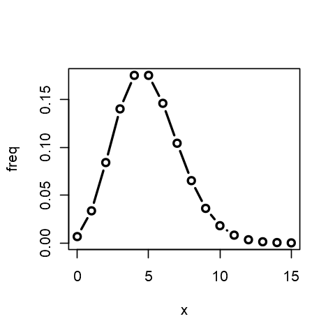

```r
x <- seq(0, 15, 1)
freq <- dpois(x, lambda=5)
plot(x, freq, type="b", lwd=2)
```

式 10.6

$$ P(x) = \frac{\lambda^{x}}{x !}e^{-\lambda} $$

## 10.4 ロジスティック回帰の例

```r
d <- read.csv("../samplecode/Rで学ぶ統計学入門図版作成用/table10-2.csv")
head(d)
```

| dose | dead | live |
| --- | --- | --- |
| 1.0 | 0 | 1 |
| 1.3 | 0 | 1 |
| 1.7 | 0 | 1 |
| 2.2 | 0 | 1 |
| 2.4 | 0 | 1 |
| 2.8 | 0 | 1 |

```r
str(d)
```

```
'data.frame':	17 obs. of  3 variables:
 $ dose: num  1 1.3 1.7 2.2 2.4 2.8 3.1 3.5 3.7 4.2 ...
 $ dead: int  0 0 0 0 0 0 1 1 0 0 ...
 $ live: int  1 1 1 1 1 1 0 0 1 1 ...
```

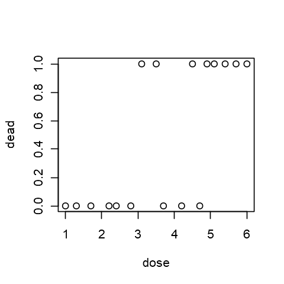

```r
with(plot(dose, dead), data = d)
```

pp.147--148

データに `live` 列があるので，`1-dead` は必要ないはず． 実際，p.148 の出力例は`live`列を使っている．

```r
result <- glm(cbind(dead, live) ~ dose, family = binomial(logit), data = d)
summary(result)
```

```
Call:
glm(formula = cbind(dead, live) ~ dose, family = binomial(logit),
    data = d)

Deviance Residuals:
    Min       1Q   Median       3Q      Max
-1.7000  -0.4663  -0.1727   0.5642   1.6872

Coefficients:
            Estimate Std. Error z value Pr(>|z|)
(Intercept)  -5.6500     2.6630  -2.122   0.0339 *
dose          1.4524     0.6528   2.225   0.0261 *
---
Signif. codes:  0 '***' 0.001 '**' 0.01 '*' 0.05 '.' 0.1 ' ' 1

(Dispersion parameter for binomial family taken to be 1)

    Null deviance: 23.508  on 16  degrees of freedom
Residual deviance: 13.564  on 15  degrees of freedom
AIC: 17.564

Number of Fisher Scoring iterations: 5
```

```r
coef(result)
```

**(Intercept)**

-5.64999003540222

**dose**

1.45236254100564

```r
names(coef(result))
```

1. '(Intercept)'

2. 'dose'

```r
d.predicted <- data.frame(dose = seq(1, 6, 0.01))
d.predicted$dead <- with(
    1 / (1 + exp(-(coef(result)["(Intercept)"] + coef(result)["dose"] * dose))),
    data=d.predicted)
summary(d.predicted)
```

```
      dose           dead
 Min.   :1.00   Min.   :0.01481
 1st Qu.:2.25   1st Qu.:0.08454
 Median :3.50   Median :0.36199
 Mean   :3.50   Mean   :0.42631
 3rd Qu.:4.75   3rd Qu.:0.77708
 Max.   :6.00   Max.   :0.95539
```

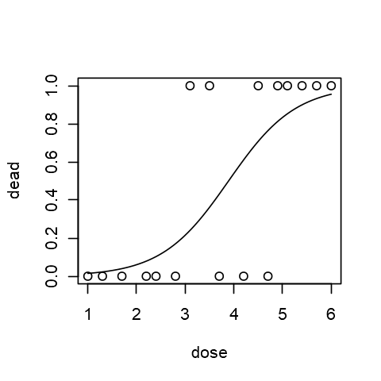

```r
with(data=d, plot(dose, dead))
with(data=d.predicted, lines(dose, dead))
```

## 10.5 ポアソン回帰の例

```r
d2 <- read.csv("../samplecode/Rで学ぶ統計学入門図版作成用/table10-3.csv")
head(d2)
```

| wt | flw |
| --- | --- |
| 17.3 | 1 |
| 18.5 | 2 |
| 20.5 | 0 |
| 21.2 | 3 |
| 20.8 | 0 |
| 21.5 | 1 |

```r
str(d2)
```

```
'data.frame':	42 obs. of  2 variables:
 $ wt : num  17.3 18.5 20.5 21.2 20.8 21.5 22.1 22.7 22.6 23.3 ...
 $ flw: int  1 2 0 3 0 1 1 0 3 1 ...
```

```r
summary(d2)
```

```
       wt             flw
 Min.   :17.30   Min.   :0.000
 1st Qu.:23.52   1st Qu.:2.000
 Median :28.00   Median :4.000
 Mean   :27.88   Mean   :3.952
 3rd Qu.:31.73   3rd Qu.:6.000
 Max.   :36.80   Max.   :9.000
```

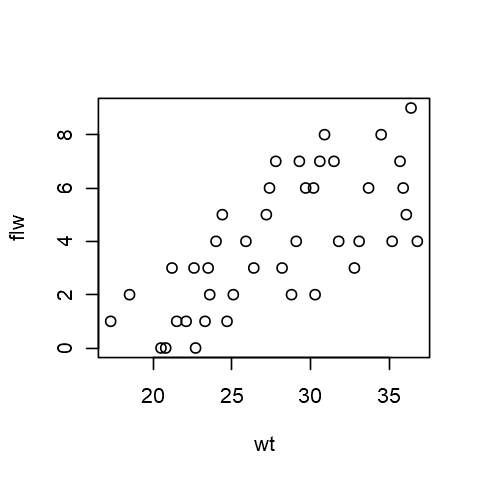

```r
with(plot(wt, flw), data=d2)
```

```r
result2 <- glm(flw ~ wt, family = poisson, data=d2)
summary(result2)
```

```
Call:
glm(formula = flw ~ wt, family = poisson, data = d2)

Deviance Residuals:
     Min        1Q    Median        3Q       Max
-2.15981  -0.90205  -0.04287   0.72827   1.60420

Coefficients:
            Estimate Std. Error z value Pr(>|z|)
(Intercept) -1.04344    0.47066  -2.217   0.0266 *
wt           0.08327    0.01540   5.408 6.38e-08 ***
---
Signif. codes:  0 '***' 0.001 '**' 0.01 '*' 0.05 '.' 0.1 ' ' 1

(Dispersion parameter for poisson family taken to be 1)

    Null deviance: 72.866  on 41  degrees of freedom
Residual deviance: 42.115  on 40  degrees of freedom
AIC: 169.69

Number of Fisher Scoring iterations: 5
```

```r
d2.predicted <- data.frame(wt = seq(20, 40, 0.1))
d2.predicted$flw <- with(exp(coef(result2)["(Intercept)"] + coef(result2)["wt"] * wt), data=d2.predicted)
head(d.predicted)
```

| dose | dead |
| --- | --- |
| 1.00 | 0.01480861 |
| 1.01 | 0.01502199 |
| 1.02 | 0.01523841 |
| 1.03 | 0.01545790 |
| 1.04 | 0.01568049 |
| 1.05 | 0.01590625 |

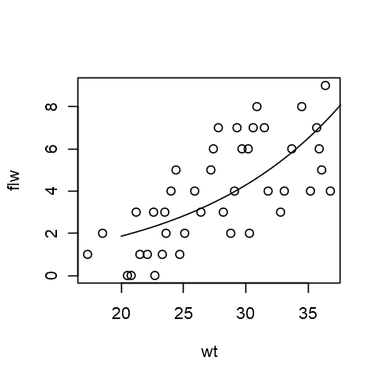

```r
with(plot(flw ~ wt), data=d2)
with(lines(flw ~ wt), data=d2.predicted)
```

```r
str(summary(result2))
```

```
List of 17
 $ call          : language glm(formula = flw ~ wt, family = poisson, data = d2)
 $ terms         :Classes 'terms', 'formula'  language flw ~ wt
  .. ..- attr(*, "variables")= language list(flw, wt)
  .. ..- attr(*, "factors")= int [1:2, 1] 0 1
  .. .. ..- attr(*, "dimnames")=List of 2
  .. .. .. ..$ : chr [1:2] "flw" "wt"
  .. .. .. ..$ : chr "wt"
  .. ..- attr(*, "term.labels")= chr "wt"
  .. ..- attr(*, "order")= int 1
  .. ..- attr(*, "intercept")= int 1
  .. ..- attr(*, "response")= int 1
  .. ..- attr(*, ".Environment")=<environment: R_GlobalEnv>
  .. ..- attr(*, "predvars")= language list(flw, wt)
  .. ..- attr(*, "dataClasses")= Named chr [1:2] "numeric" "numeric"
  .. .. ..- attr(*, "names")= chr [1:2] "flw" "wt"
 $ family        :List of 12
  ..$ family    : chr "poisson"
  ..$ link      : chr "log"
  ..$ linkfun   :function (mu)
  ..$ linkinv   :function (eta)
  ..$ variance  :function (mu)
  ..$ dev.resids:function (y, mu, wt)
  ..$ aic       :function (y, n, mu, wt, dev)
  ..$ mu.eta    :function (eta)
  ..$ initialize:  expression({     if (any(y < 0))          stop("negative values not allowed for the 'Poisson' family")     n <- rep.int(1, nobs)     mustart <- y + 0.1 })
  ..$ validmu   :function (mu)
  ..$ valideta  :function (eta)
  ..$ simulate  :function (object, nsim)
  ..- attr(*, "class")= chr "family"
 $ deviance      : num 42.1
 $ aic           : num 170
 $ contrasts     : NULL
 $ df.residual   : int 40
 $ null.deviance : num 72.9
 $ df.null       : int 41
 $ iter          : int 5
 $ deviance.resid: Named num [1:42] -0.425 0.268 -1.971 0.614 -1.996 ...
  ..- attr(*, "names")= chr [1:42] "1" "2" "3" "4" ...
 $ coefficients  : num [1:2, 1:4] -1.0434 0.0833 0.4707 0.0154 -2.217 ...
  ..- attr(*, "dimnames")=List of 2
  .. ..$ : chr [1:2] "(Intercept)" "wt"
  .. ..$ : chr [1:4] "Estimate" "Std. Error" "z value" "Pr(>|z|)"
 $ aliased       : Named logi [1:2] FALSE FALSE
  ..- attr(*, "names")= chr [1:2] "(Intercept)" "wt"
 $ dispersion    : num 1
 $ df            : int [1:3] 2 40 2
 $ cov.unscaled  : num [1:2, 1:2] 0.221523 -0.007149 -0.007149 0.000237
  ..- attr(*, "dimnames")=List of 2
  .. ..$ : chr [1:2] "(Intercept)" "wt"
  .. ..$ : chr [1:2] "(Intercept)" "wt"
 $ cov.scaled    : num [1:2, 1:2] 0.221523 -0.007149 -0.007149 0.000237
  ..- attr(*, "dimnames")=List of 2
  .. ..$ : chr [1:2] "(Intercept)" "wt"
  .. ..$ : chr [1:2] "(Intercept)" "wt"
 - attr(*, "class")= chr "summary.glm"
```

過分散

```r
summary(result2)$deviance / summary(result2)$`df.residual`
```

1.05288216598768

## 10.6 尤度

```r
y <- c(0:9)
p <- dpois(y, lambda=2)
p
```

1. 0.135335283236613

2. 0.270670566473225

3. 0.270670566473225

4. 0.180447044315484

5. 0.0902235221577418

6. 0.0360894088630967

7. 0.0120298029543656

8. 0.00343708655839016

9. 0.000859271639597541

10. 0.000190949253243898

```r
options(digits=4)
```

最低でも4桁出るようになっている

```r
print(p)
```

```
 [1] 0.1353353 0.2706706 0.2706706 0.1804470 0.0902235 0.0360894 0.0120298
 [8] 0.0034371 0.0008593 0.0001909
```

```r
logL <- function(x, d){sum(dpois(d, x, log=T))}
d <- rpois(50, lambda = 3.1)
lambdas <- seq(2, 5, 0.1)
```

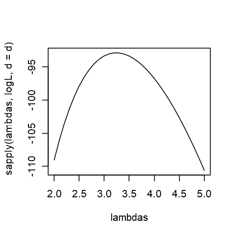

```r
plot(lambdas, sapply(lambdas, logL, d = d), type="l")
```

## 10.7 AIC

```r
logLik(result)
```

```
'log Lik.' -6.782 (df=2)
```

```r
-2 * logLik(result) + 2 * 2
```

```
'log Lik.' 17.56 (df=2)
```

```r
logLik(result2)
```

```
'log Lik.' -82.85 (df=2)
```

```r
-2 * logLik(result2) + 2 * 2
```

```
'log Lik.' 169.7 (df=2)
```

## 10.8 逸脱度，残差逸脱度，最大逸脱度

pp.158 付近の逸脱度の説明が曖昧な気がする（表と一致していない）

最小逸脱度: フルモデル

```r
sum(log(dpois(d2$flw, lambda=d2$flw))) * -2
```

123.576423907449

最大逸脱度: ナルモデル

```r
result2.null <- glm(flw ~ 1, family = poisson, data=d2)
summary(result2.null)
```

```
Call:
glm(formula = flw ~ 1, family = poisson, data = d2)

Deviance Residuals:
    Min       1Q   Median       3Q      Max
-2.8115  -1.0863   0.0239   0.9561   2.1719

Coefficients:
            Estimate Std. Error z value Pr(>|z|)
(Intercept)   1.3743     0.0776    17.7   <2e-16 ***
---
Signif. codes:  0 '***' 0.001 '**' 0.01 '*' 0.05 '.' 0.1 ' ' 1

(Dispersion parameter for poisson family taken to be 1)

    Null deviance: 72.866  on 41  degrees of freedom
Residual deviance: 72.866  on 41  degrees of freedom
AIC: 198.4

Number of Fisher Scoring iterations: 5
```

```r
logLik(result2.null)
```

```
'log Lik.' -98.22 (df=1)
```

```r
-2 * logLik(result2.null)
```

```
'log Lik.' 196.4 (df=1)
```

ナル逸脱度: ナルモデルと最小逸脱度の差

残差逸脱度: glmの結果の逸脱度の最小逸脱度との差

```r
result2
```

```
Call:  glm(formula = flw ~ wt, family = poisson, data = d2)

Coefficients:
(Intercept)           wt
    -1.0434       0.0833

Degrees of Freedom: 41 Total (i.e. Null);  40 Residual
Null Deviance:	    72.9
Residual Deviance: 42.1 	AIC: 170
```

```r
-2 * logLik(result2)
```

```
'log Lik.' 165.7 (df=2)
```

```r
165.7 - 123.57
```

42.13

## 10.9 二つ以上の説明変数を持つときのモデル選択: ロジスティック回帰を事例に

```r
d3 <- read.csv("../samplecode/Rで学ぶ統計学入門図版作成用/table10-5.csv")
head(d3)
```

| dose | sex | y |
| --- | --- | --- |
| 1 | 1 | 0 |
| 1 | 1 | 0 |
| 1 | 1 | 0 |
| 1 | 1 | 0 |
| 1 | 1 | 0 |
| 1 | 1 | 0 |

```r
str(d3)
```

```
'data.frame':	80 obs. of  3 variables:
 $ dose: int  1 1 1 1 1 1 1 1 1 1 ...
 $ sex : int  1 1 1 1 1 1 1 1 1 1 ...
 $ y   : int  0 0 0 0 0 0 0 1 1 1 ...
```

```r
summary(d3)
```

```
      dose           sex            y
 Min.   :1.00   Min.   :1.0   Min.   :0.0000
 1st Qu.:1.75   1st Qu.:1.0   1st Qu.:0.0000
 Median :2.50   Median :1.5   Median :0.0000
 Mean   :2.50   Mean   :1.5   Mean   :0.4875
 3rd Qu.:3.25   3rd Qu.:2.0   3rd Qu.:1.0000
 Max.   :4.00   Max.   :2.0   Max.   :1.0000
```

- A: `dose` モデル
- B: `dose + sex` モデル
- C: `dose + sex + dose:sex` モデル

```r
result3.A <- glm(cbind(y, 1 - y) ~ dose, family = binomial(logit), data = d3)
summary(result3.A)
```

```
Call:
glm(formula = cbind(y, 1 - y) ~ dose, family = binomial(logit),
    data = d3)

Deviance Residuals:
    Min       1Q   Median       3Q      Max
-1.9035  -0.9215  -0.5604   0.9744   1.9641

Coefficients:
            Estimate Std. Error z value Pr(>|z|)
(Intercept)  -2.9068     0.7253  -4.008 6.13e-05 ***
dose          1.1350     0.2670   4.252 2.12e-05 ***
---
Signif. codes:  0 '***' 0.001 '**' 0.01 '*' 0.05 '.' 0.1 ' ' 1

(Dispersion parameter for binomial family taken to be 1)

    Null deviance: 110.854  on 79  degrees of freedom
Residual deviance:  86.708  on 78  degrees of freedom
AIC: 90.708

Number of Fisher Scoring iterations: 3
```

```r
result3.B <- glm(cbind(y, 1 - y) ~ dose + sex, family = binomial(logit), data = d3)
summary(result3.B)
```

```
Call:
glm(formula = cbind(y, 1 - y) ~ dose + sex, family = binomial(logit),
    data = d3)

Deviance Residuals:
    Min       1Q   Median       3Q      Max
-1.9054  -0.7505  -0.2851   0.8059   1.9775

Coefficients:
            Estimate Std. Error z value Pr(>|z|)
(Intercept)  -0.4433     0.9753  -0.455   0.6495
dose          1.3802     0.3208   4.302 1.69e-05 ***
sex          -2.0599     0.6488  -3.175   0.0015 **
---
Signif. codes:  0 '***' 0.001 '**' 0.01 '*' 0.05 '.' 0.1 ' ' 1

(Dispersion parameter for binomial family taken to be 1)

    Null deviance: 110.854  on 79  degrees of freedom
Residual deviance:  74.236  on 77  degrees of freedom
AIC: 80.236

Number of Fisher Scoring iterations: 5
```

```r
result3.C <- glm(cbind(y, 1 - y) ~ dose + sex + dose:sex, family = binomial(logit), data = d3)
summary(result3.C)
```

```
Call:
glm(formula = cbind(y, 1 - y) ~ dose + sex + dose:sex, family = binomial(logit),
    data = d3)

Deviance Residuals:
    Min       1Q   Median       3Q      Max
-1.9066  -0.7495  -0.2860   0.8070   1.9761

Coefficients:
            Estimate Std. Error z value Pr(>|z|)
(Intercept) -0.46567    2.48159  -0.188    0.851
dose         1.38960    1.00878   1.378    0.168
sex         -2.04388    1.75637  -1.164    0.245
dose:sex    -0.00629    0.64177  -0.010    0.992

(Dispersion parameter for binomial family taken to be 1)

    Null deviance: 110.854  on 79  degrees of freedom
Residual deviance:  74.236  on 76  degrees of freedom
AIC: 82.236

Number of Fisher Scoring iterations: 5
```

```r
library(ggplot2)
```

```r
library(dplyr)
```

グラフは，殺虫剤の濃度ごとの死亡率を性別別にプロットした方がいいのではないか

と思ったが，予測のときは濃度は連続値になっているので，無理か

本文では「死亡率」となっているが，「率」ではないような

```r
d3 %>% group_by(dose, sex) %>% summarise(mortality=mean(y))
```

| dose | sex | mortality |
| --- | --- | --- |
| 1 | 1 | 0.3 |
| 1 | 2 | 0.0 |
| 2 | 1 | 0.5 |
| 2 | 2 | 0.2 |
| 3 | 1 | 0.8 |
| 3 | 2 | 0.4 |
| 4 | 1 | 1.0 |
| 4 | 2 | 0.7 |

```r
options(repr.plot.width=5)
```

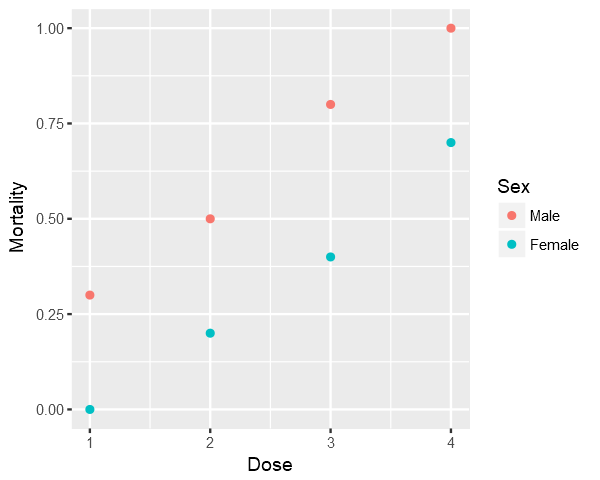

```r
d3 %>% group_by(dose, sex) %>% summarise(mortality=mean(y)) %>% ungroup() %>%
    ggplot(aes(x = dose, y = mortality, group=sex, colour=factor(sex))) +
        geom_point() +
        scale_color_discrete(name="Sex", label=c("Male", "Female")) +
        xlab("Dose") + ylab("Mortality")
```

```r
d3.pred.A <-
    data.frame(dose = seq(1, 4, 0.01)) %>%
    mutate(y = 1 / (1 + exp(-(coef(result3.A)["(Intercept)"] + coef(result3.A)["dose"] * dose))))
head(d3.pred.A)
```

| dose | y |
| --- | --- |
| 1.00 | 0.1453217 |
| 1.01 | 0.1467371 |
| 1.02 | 0.1481640 |
| 1.03 | 0.1496022 |
| 1.04 | 0.1510520 |
| 1.05 | 0.1525133 |

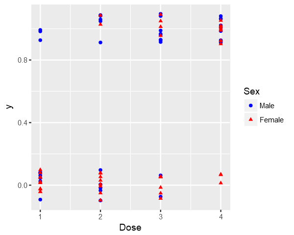

```r
gp.d3 <- d3 %>% ggplot(aes(x=dose, y=y, group=sex, shape=factor(sex), colour=factor(sex))) +
    geom_jitter(width=0, height=0.1) +
    scale_shape_discrete(name = "Sex", labels = c("Male", "Female")) +
    scale_colour_manual(name = "Sex", labels = c("Male", "Female"), values = c("blue", "red")) +
    xlab("Dose")
gp.d3
```

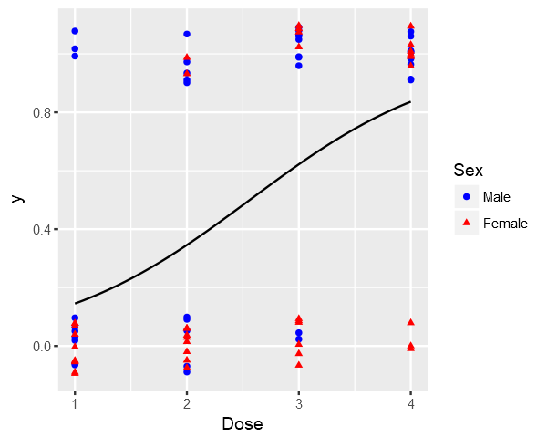

```r
gp.d3 +
    geom_line(data=d3.pred.A, aes(x = dose, y = y), inherit.aes = FALSE)
```

```r
d3.pred.B <-
    data.frame(dose = seq(1, 4, 0.01)) %>%
    mutate(yM = 1 / (1 + exp(-(coef(result3.B)["(Intercept)"] +
                               coef(result3.B)["dose"] * dose +
                               coef(result3.B)["sex"] * 1))),
           yF = 1 / (1 + exp(-(coef(result3.B)["(Intercept)"] +
                               coef(result3.B)["dose"] * dose +
                               coef(result3.B)["sex"] * 2))))

head(d3.pred.B)
```

| dose | yM | yF |
| --- | --- | --- |
| 1.00 | 0.2454642 | 0.03981687 |
| 1.01 | 0.2480295 | 0.04034792 |
| 1.02 | 0.2506128 | 0.04088575 |
| 1.03 | 0.2532138 | 0.04143044 |
| 1.04 | 0.2558327 | 0.04198207 |
| 1.05 | 0.2584693 | 0.04254072 |

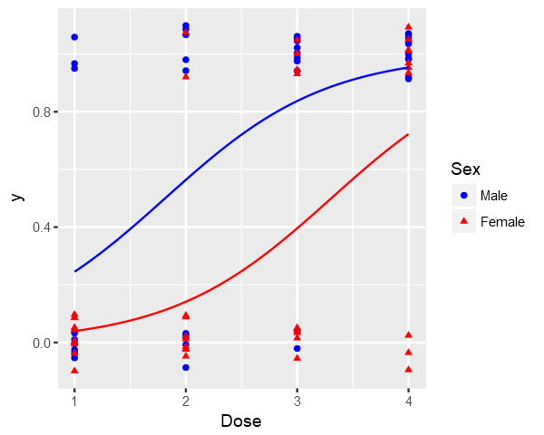

```r
gp.d3 +
    geom_line(data=d3.pred.B, aes(x = dose, y = yM), inherit.aes = FALSE, colour="blue") +
    geom_line(data=d3.pred.B, aes(x = dose, y = yF), inherit.aes = FALSE, colour="red")
```

```r
d3.pred.C <-
    data.frame(dose = seq(1, 4, 0.01)) %>%
    mutate(yM = 1 / (1 + exp(-(coef(result3.C)["(Intercept)"] +
                               coef(result3.C)["dose"] * dose +
                               coef(result3.C)["sex"] * 1 +
                               coef(result3.C)["dose:sex"] * 1 * dose))),
           yF = 1 / (1 + exp(-(coef(result3.C)["(Intercept)"] +
                               coef(result3.C)["dose"] * dose +
                               coef(result3.C)["sex"] * 2 +
                               coef(result3.C)["dose:sex"] * 2 * dose))))
head(d3.pred.C)
```

| dose | yM | yF |
| --- | --- | --- |
| 1.00 | 0.2448573 | 0.04006360 |
| 1.01 | 0.2474241 | 0.04059655 |
| 1.02 | 0.2500089 | 0.04113628 |
| 1.03 | 0.2526117 | 0.04168288 |
| 1.04 | 0.2552323 | 0.04223642 |
| 1.05 | 0.2578707 | 0.04279699 |

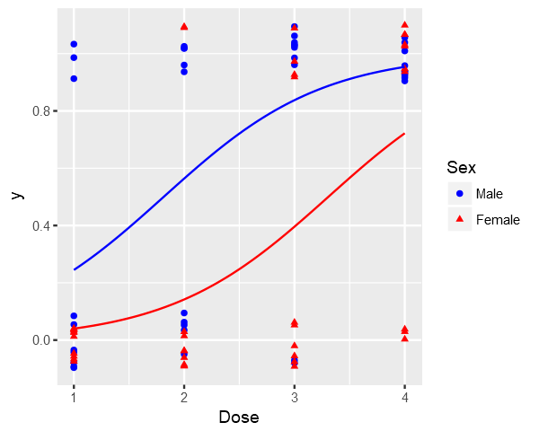

```r
gp.d3 +
    geom_line(data=d3.pred.C, aes(x = dose, y = yM), inherit.aes = FALSE, colour="blue") +
    geom_line(data=d3.pred.C, aes(x = dose, y = yF), inherit.aes = FALSE, colour="red")
```

## 10.10 GLMにおけるオフセットの利用

```r
d4 <- read.csv("../samplecode/Rで学ぶ統計学入門図版作成用/table10-6.csv")
head(d4)
```

| light | plants | w_area |
| --- | --- | --- |
| 3500 | 4 | 6.5 |
| 2300 | 2 | 7.3 |
| 700 | 2 | 12.3 |
| 500 | 0 | 4.3 |
| 2900 | 4 | 17.5 |
| 2300 | 3 | 13.1 |

```r
summary(d4)
```

```
     light          plants          w_area
 Min.   : 300   Min.   :0.000   Min.   : 3.300
 1st Qu.: 800   1st Qu.:0.500   1st Qu.: 6.200
 Median :1800   Median :2.000   Median : 8.100
 Mean   :1807   Mean   :2.133   Mean   : 9.347
 3rd Qu.:2650   3rd Qu.:4.000   3rd Qu.:12.700
 Max.   :4000   Max.   :5.000   Max.   :17.500
```

```r
str(d4)
```

```
'data.frame':	15 obs. of  3 variables:
 $ light : int  3500 2300 700 500 2900 2300 1200 900 300 2500 ...
 $ plants: int  4 2 2 0 4 3 1 2 0 4 ...
 $ w_area: num  6.5 7.3 12.3 4.3 17.5 13.1 8.1 13.7 4.3 15.2 ...
```

スクリプト例，`d$w_area` とするか `data=d` としないとエラーになるはず

```r
result4 <- glm(plants ~ light, offset = log(w_area), family = poisson, data=d4)
summary(result4)
```

```
Call:
glm(formula = plants ~ light, family = poisson, data = d4, offset = log(w_area))

Deviance Residuals:
     Min        1Q    Median        3Q       Max
-1.12046  -0.68175  -0.00947   0.35440   0.72186

Coefficients:
              Estimate Std. Error z value Pr(>|z|)
(Intercept) -2.7152248  0.4910606  -5.529 3.21e-08 ***
light        0.0005273  0.0001735   3.040  0.00237 **
---
Signif. codes:  0 '***' 0.001 '**' 0.01 '*' 0.05 '.' 0.1 ' ' 1

(Dispersion parameter for poisson family taken to be 1)

    Null deviance: 15.5631  on 14  degrees of freedom
Residual deviance:  5.6669  on 13  degrees of freedom
AIC: 41.043

Number of Fisher Scoring iterations: 4
```

```r
d4.pred <-
    data.frame(light=seq(0, 4000, 0.1)) %>%
    mutate(density = exp(coef(result4)["(Intercept)"] + coef(result4)["light"] * light))
head(d4.pred)
```

| light | density |
| --- | --- |
| 0.0 | 0.06619007 |
| 0.1 | 0.06619356 |
| 0.2 | 0.06619705 |
| 0.3 | 0.06620055 |
| 0.4 | 0.06620404 |
| 0.5 | 0.06620753 |

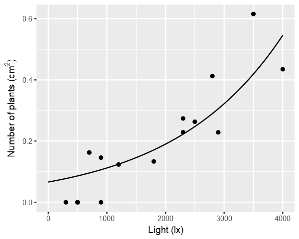

```r
ggplot() +
    geom_point(data=d4, aes(x=light , y=plants / w_area)) +
    geom_line(data=d4.pred, aes(x=light, y=density)) +
    xlab("Light (lx)") + ylab(expression("Number of plants (cm"^{-2}*")"))
```

[output not shown]